# Proyecto 1 - Relación Minutos Ingreso

```
                                 VALERIE FAJARDO VFAJARD45354 HECTOR BELLO HBELLOS52070 HAROLD MENDOZA HMENDOZ25900
                                                               MACHINE LEARNING I
```

## Explicación del Problema:

En este análisis, estamos interesados en determinar si existe una relación entre el total de minutos utilizados por los clientes con la compañía de telecomunicaciones y los ingresos totales generados por estos clientes. A través de un gráfico de dispersión, observamos que a medida que aumenta el número de minutos usados por un cliente, también tiende a incrementarse el ingreso total generado. Esto sugiere que existe una relación positiva entre estas dos variables: los clientes que usan más minutos tienden a generar más ingresos para la compañía.

Sin embargo, es importante resaltar que la relación no es perfectamente lineal, ya que se observan dispersiones, especialmente para los clientes que utilizan una mayor cantidad de minutos. Algunos de ellos generan ingresos considerablemente más altos o más bajos que otros con un uso de minutos similar. Esto podría deberse a factores adicionales, como tarifas diferenciadas o el uso de otros servicios complementarios.

En resumen, hay una relación general entre el uso de minutos y los ingresos, pero con variabilidad, lo que sugiere la influencia de factores adicionales en los ingresos de los clientes.

```python
import pandas as pd
import numpy as np
import matplotlib.pyplot as plt
import seaborn as sns
from sklearn import linear_model
from sklearn.metrics import mean_squared_error, r2_score
```

```python
df = pd.read_csv('Credito_dias.csv', sep =';')
```

## 1. Definicion de las variables

```python
descripcion = pd.DataFrame()
descripcion['columnas'] = df.columns
print('Estas son los nombres que se usan en el Df y su signigicado \n')
descripcion['Detalle'] = ['Total de minutos usados por el cliente.','Ingresos del cliente.','Indicador de tarjeta de crédito.','Número de días (antigüedad) del equipo actual.','Codigo de Identificacion de CLiente.']
print(descripcion)
```

```
Estas son los nombres que se usan en el Df y su signigicado

      columnas                                         Detalle
0       totmou         Total de minutos usados por el cliente.
1       totrev                           Ingresos del cliente.
2     creditcd                Indicador de tarjeta de crédito.
3      eqpdays  Número de días (antigüedad) del equipo actual.
4  Customer_ID            Codigo de Identificacion de CLiente.
```

```python
df.head()
```

|  | totmou | totrev | creditcd | eqpdays | Customer_ID |
| --- | --- | --- | --- | --- | --- |
| 0 | 7269 | 906.58 | Y | 371 | 1082423 |
| 1 | 13552 | 1172.25 | N | 83 | 1069232 |
| 2 | 4152 | 577.39 | Y | 675 | 1031705 |
| 3 | 1863 | 294.26 | Y | 218 | 1089806 |
| 4 | 4155 | 433.16 | N | 222 | 1076695 |

```python
df.info()
```

```
<class 'pandas.core.frame.DataFrame'>
RangeIndex: 10000 entries, 0 to 9999
Data columns (total 5 columns):
 #   Column       Non-Null Count  Dtype
---  ------       --------------  -----
 0   totmou       10000 non-null  object
 1   totrev       10000 non-null  float64
 2   creditcd     9848 non-null   object
 3   eqpdays      10000 non-null  int64
 4   Customer_ID  10000 non-null  int64
dtypes: float64(1), int64(2), object(2)
memory usage: 390.8+ KB
```

```python
def vol_valor(valor):
    try:
        resul = int(valor)
        return resul
    except(ValueError, TypeError):
        return np.nan


df['totmou'] = df['totmou'].apply(vol_valor)
df['Customer_ID'] = df['Customer_ID'].astype(str)
df.info()
```

```
<class 'pandas.core.frame.DataFrame'>
RangeIndex: 10000 entries, 0 to 9999
Data columns (total 5 columns):
 #   Column       Non-Null Count  Dtype
---  ------       --------------  -----
 0   totmou       9897 non-null   float64
 1   totrev       10000 non-null  float64
 2   creditcd     9848 non-null   object
 3   eqpdays      10000 non-null  int64
 4   Customer_ID  10000 non-null  object
dtypes: float64(2), int64(1), object(2)
memory usage: 390.8+ KB
```

```python
df.describe()
```

[output not shown]

|  | totmou | totrev | eqpdays | Customer_ID |
| --- | --- | --- | --- | --- |
| count | 9897.000000 | 10000.000000 | 10000.000000 | 1.000000e+04 |
| mean | 7391.727190 | 1042.133807 | 386.794500 | 1.049965e+06 |
| std | 7597.503482 | 857.144895 | 252.720196 | 2.879424e+04 |
| min | 0.000000 | 11.100000 | -5.000000 | 1.000014e+06 |
| 25% | 2558.000000 | 526.787500 | 210.000000 | 1.025053e+06 |
| 50% | 5197.000000 | 820.235000 | 338.000000 | 1.049652e+06 |
| 75% | 9656.000000 | 1272.975000 | 522.000000 | 1.074798e+06 |
| max | 136445.000000 | 13426.600000 | 1823.000000 | 1.099992e+06 |

```python
df.isnull().sum()
```

```
totmou         103
totrev           0
creditcd       152
eqpdays          0
Customer_ID      0
dtype: int64
```

```python
df_clean = df.dropna()
```

```python
df_clean.isnull().sum()
```

```
totmou         0
totrev         0
creditcd       0
eqpdays        0
Customer_ID    0
dtype: int64
```

## 5. Exploración Descriptiva con Gráficos por Variable

## Distribución de los Ingresos de los Clientes

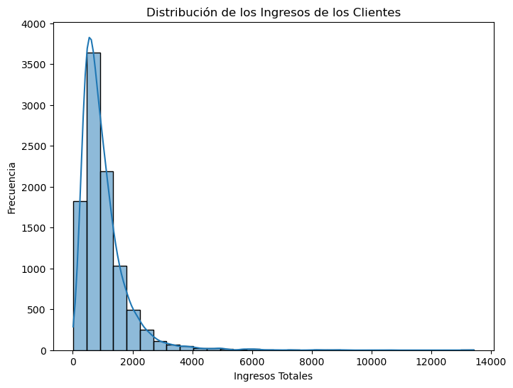

```python
# Histograma para ingresos
plt.figure(figsize=(8, 6))
sns.histplot(df_clean['totrev'], bins=30,kde = True)
plt.title('Distribución de los Ingresos de los Clientes')
plt.xlabel('Ingresos Totales')
plt.ylabel('Frecuencia')
plt.show()
```

Al explorar la variable de ingresos totales de los clientes, se observa que la distribución es marcadamente asimétrica hacia la derecha, lo que indica que la mayoría de los clientes generan ingresos relativamente bajos, mientras que solo un pequeño grupo contribuye con ingresos mucho más altos. Esta concentración de ingresos en rangos bajos sugiere la existencia de una base de clientes en su mayoría de menor valor, con algunos clientes de mayor ingreso actuando como posibles outliers. Esta observación podría tener importantes implicaciones para la segmentación de clientes y el desarrollo de estrategias comerciales personalizadas. Asimismo, revisar los outliers podría ayudar a identificar clientes de alto valor que merezcan estrategias diferenciadas para maximizar su retención.

## Distribución de los Minutos Usados

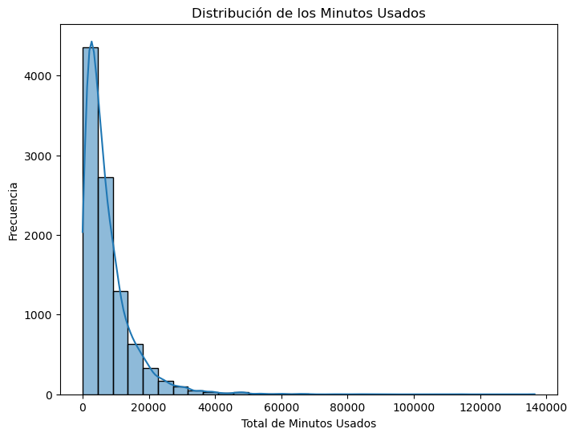

```python
# Histograma para minutos usados
plt.figure(figsize=(8, 6))
sns.histplot(df_clean['totmou'], bins=30, kde=True)
plt.title('Distribución de los Minutos Usados')
plt.xlabel('Total de Minutos Usados')
plt.ylabel('Frecuencia')
plt.show()
```

## Distribución de los Minutos Usados

En el gráfico de distribución del total de minutos usados por los clientes, podemos observar que la mayoría de los usuarios utiliza una cantidad relativamente baja de minutos, concentrándose principalmente en los primeros valores. La distribución está claramente sesgada hacia la derecha, lo que significa que la mayor parte de la frecuencia se encuentra en los valores bajos de minutos utilizados, mientras que hay pocos clientes que utilizan una cantidad significativamente alta de minutos, llegando incluso a valores extremos.

Esta tendencia indica que el uso de minutos no es homogéneo entre los clientes, ya que la mayor parte de ellos hace un uso moderado o bajo de minutos, mientras que una pequeña fracción consume una cantidad mucho mayor. La cola larga de la distribución sugiere que existen algunos clientes “extremos” o de alto consumo, que usan muchos más minutos que el promedio. Esto puede llevar a conclusiones sobre el comportamiento de consumo en relación con los planes ofrecidos por la compañía y podría ser útil para identificar segmentos de clientes de alto valor o para ajustar la estrategia comercial de la empresa en función de los patrones de uso de los minutos.

## Distribución de los Días con el Equipo Actual

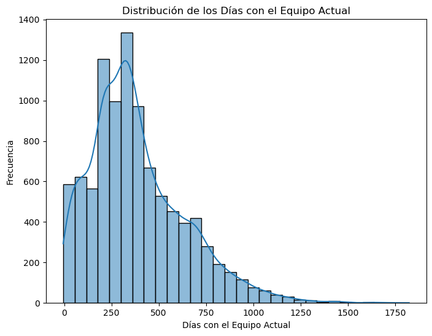

```python
# Histograma para los días con el equipo actual (antigüedad)
plt.figure(figsize=(8, 6))
sns.histplot(df_clean['eqpdays'], bins=30, kde=True)
plt.title('Distribución de los Días con el Equipo Actual')
plt.xlabel('Días con el Equipo Actual')
plt.ylabel('Frecuencia')
plt.show()
```

## Distribución de los Días con el Equipo Actual

En el gráfico de distribución de los días con el equipo actual, observamos que la mayoría de los clientes ha tenido su equipo durante un rango que oscila entre los 100 y 400 días. La forma de la distribución indica que un gran número de clientes tiene equipos relativamente nuevos o recientes, mientras que a medida que aumenta el número de días, la cantidad de clientes con equipos más antiguos disminuye gradualmente, formando una cola hacia la derecha.

Este patrón sugiere que los ciclos de renovación o cambio de equipos son bastante comunes en los primeros 400 días, y luego la frecuencia de clientes con equipos más antiguos se reduce progresivamente. Es posible que este comportamiento refleje las políticas de renovación o actualizaciones que ofrece la empresa o la preferencia de los clientes por mantener su equipo en función de la vida útil o el rendimiento. En definitiva, este gráfico puede ayudar a entender mejor los patrones de renovación de dispositivos entre los clientes y podría ser útil para diseñar estrategias de marketing o mejoras en las políticas de actualización de equipos.

## Distribución del Uso de Tarjeta de Crédito

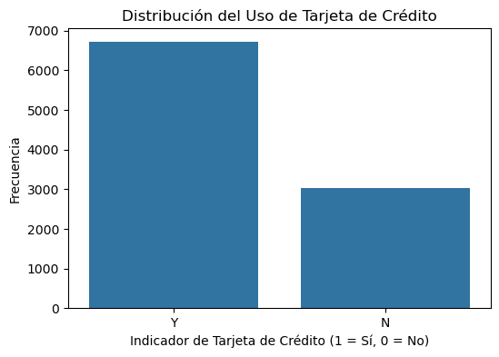

```python
# Diagrama de barras para indicador de tarjeta de crédito
plt.figure(figsize=(6, 4))
sns.countplot(x='creditcd', data=df_clean)
plt.title('Distribución del Uso de Tarjeta de Crédito')
plt.xlabel('Indicador de Tarjeta de Crédito (1 = Sí, 0 = No)')
plt.ylabel('Frecuencia')
plt.show()
```

## Distribución del Uso de Tarjeta de Crédito

En el gráfico de distribución del uso de tarjeta de crédito, podemos observar que la gran mayoría de los clientes (más de 6000) tienen una tarjeta de crédito asociada a sus cuentas (indicado por "Y" en el gráfico). Por otro lado, una menor cantidad de clientes (alrededor de 3000) no tiene una tarjeta de crédito vinculada (indicado por "N").

Este gráfico revela que un porcentaje considerable de clientes usa tarjetas de crédito, lo que puede indicar que muchos prefieren la conveniencia y beneficios que estas ofrecen. Sin embargo, también muestra una parte importante de clientes que no utiliza este medio de pago, lo que puede ser útil para analizar la posibilidad de ofrecer más incentivos para que estos usuarios consideren obtener una tarjeta de crédito. Este tipo de análisis podría ayudar a la empresa a diseñar estrategias para aumentar la adopción de tarjetas de crédito, maximizando la rentabilidad en este segmento de clientes.

## 6. Relación entre minutos usados y los ingresos (diagrama de dispersión)

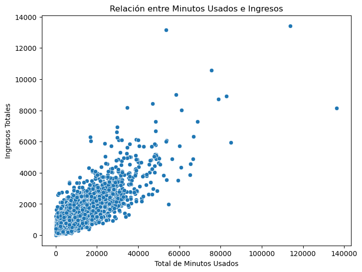

```python
# Diagrama de dispersión entre Minutos Usados e Ingresso
plt.figure(figsize=(8, 6))
sns.scatterplot(x='totmou', y='totrev', data=df_clean)
plt.title('Relación entre Minutos Usados e Ingresos')
plt.xlabel('Total de Minutos Usados')
plt.ylabel('Ingresos Totales')
plt.show()
```

### Conclusión:

En el diagrama de dispersión presentado, se observa una clara tendencia positiva entre el total de minutos utilizados por los clientes y sus ingresos totales. A medida que los clientes incrementan su uso de minutos, sus ingresos tienden a aumentar también. Sin embargo, la mayoría de los clientes se agrupan en la región de menor uso de minutos y menores ingresos, lo que sugiere que estos son los comportamientos más comunes. Así mismo, también se identifican algunos puntos atípicos que corresponden a clientes con un uso significativamente más alto de minutos y que generan ingresos muy superiores al promedio.

En conclusión, sí existe una relación positiva entre el total de minutos usados con la compañía y el ingreso total de los clientes. Esto implica que, en general, a mayor utilización de minutos, los ingresos del cliente también aumentan. Sin embargo, aunque esta tendencia es evidente para la mayoría, algunos casos extremos muestran que otros factores podrían estar influenciando la relación, ya que ciertos clientes generan ingresos significativamente más altos con un uso de minutos que no sigue estrictamente la misma tendencia.

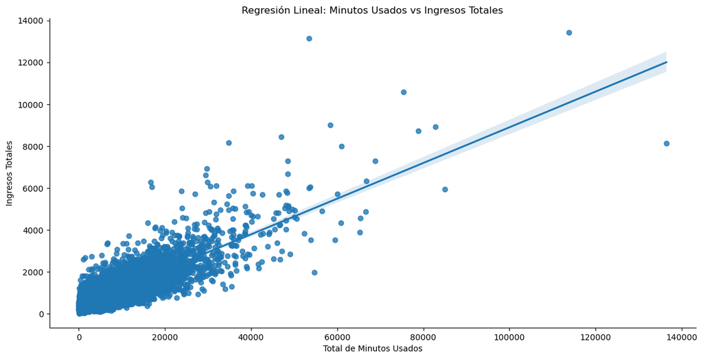

```python
# Gráfico de dispersión con línea de regresión
sns.lmplot(x='totmou', y='totrev', data=df_clean, aspect=2, height=6)
plt.xlabel('Total de Minutos Usados')
plt.ylabel('Ingresos Totales')
plt.title('Regresión Lineal: Minutos Usados vs Ingresos Totales')

plt.show()
```

## 8. Inclusión del indicador de crédito en el diagrama de dispersión

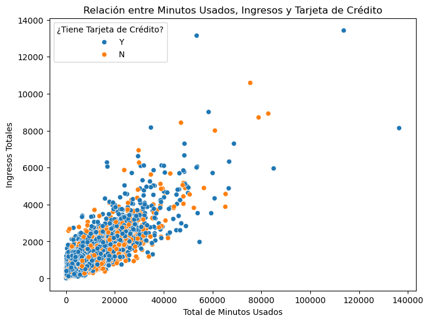

```python
plt.figure(figsize=(8, 6))
sns.scatterplot(x='totmou', y='totrev', hue='creditcd', data=df_clean)
plt.title('Relación entre Minutos Usados, Ingresos y Tarjeta de Crédito')
plt.xlabel('Total de Minutos Usados')
plt.ylabel('Ingresos Totales')
plt.legend(title='¿Tiene Tarjeta de Crédito?')
plt.show()
```

### Conclusión:

En el gráfico que incorpora el indicador de tarjeta de crédito, se observa que tanto los clientes con tarjeta de crédito (representados en azul) como aquellos sin tarjeta (en naranja) muestran una distribución bastante similar en cuanto a la relación entre minutos usados e ingresos totales. Ambos grupos tienden a seguir una tendencia positiva, donde el incremento en los minutos utilizados está asociado con un aumento en los ingresos, independientemente de si tienen o no tarjeta de crédito.

Aunque la mayoría de los puntos se agrupan de forma homogénea, se destaca que en los rangos de mayor uso de minutos (por encima de 60,000 minutos), algunos clientes sin tarjeta de crédito parecen tener ingresos más altos en comparación con los clientes con tarjeta. Sin embargo, en los niveles más bajos de uso de minutos (menos de 20,000), los ingresos totales son similares para ambos grupos, lo que sugiere que la posesión de una tarjeta de crédito no genera una diferencia sustancial en este rango de uso.

Por lo tanto, el hecho de tener una tarjeta de crédito no parece afectar significativamente la relación entre el total de minutos usados y los ingresos totales de los clientes. Aunque existen ligeras variaciones en los niveles más altos de uso de minutos, la tendencia general es la misma para ambos grupos, por lo que no se puede afirmar que el tener tarjeta de crédito influya directamente en estas variables.

## 9. Filtro por puntos fuera de la normalidad

```python
df_std = round(df_clean['totrev'].std(),2)
df_mean = round(df_clean['totrev'].mean(),2)
rango = df_std *2
lim_inf = round(df_mean - rango,2)
lim_sup = df_mean + rango

print(df_std)
print(df_mean)
print(lim_inf)
print(lim_sup)


def cumple_lim(dato):
    if (dato < lim_inf or dato > lim_sup):
        result = 0
    else:
        result = 1
    return result

df_clean['lim_ingreso'] = df_clean['totrev'].apply(cumple_lim)
print(df_clean.head())
df_ajust = df_clean[df_clean['lim_ingreso'] == 1]
```

```
789.33
1013.13
-565.53
2591.79
    totmou   totrev creditcd  eqpdays  Customer_ID  lim_ingreso
0   7269.0   906.58        Y      371      1082423            1
1  13552.0  1172.25        N       83      1069232            1
2   4152.0   577.39        Y      675      1031705            1
3   1863.0   294.26        Y      218      1089806            1
4   4155.0   433.16        N      222      1076695            1
```

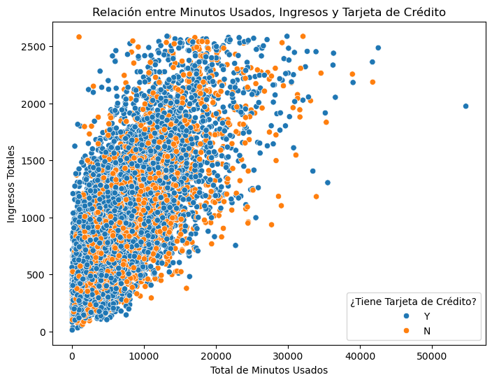

```python
plt.figure(figsize=(8, 6))
sns.scatterplot(x='totmou', y='totrev', hue='creditcd', data=df_ajust)
plt.title('Relación entre Minutos Usados, Ingresos y Tarjeta de Crédito')
plt.xlabel('Total de Minutos Usados')
plt.ylabel('Ingresos Totales')
plt.legend(title='¿Tiene Tarjeta de Crédito?')
plt.show()
```

## 10. Funcion de la regresion lineal

A continuacion encontraremos la funcion de la regresion lineal y probaremos el modelo con una porcion de los datos para validar el nivel de confiabilidad y error del modelo.

```python
# asignamos las variables X y Y
dataX = df_ajust[['totmou']]
Xentre= np.array(dataX)
Yentre = df_ajust[['totrev']].values

#se crea un objeto de la regresion
regr = linear_model.LinearRegression()

#se entrena el modelo
regr.fit(Xentre, Yentre)

# se hace la prediccion de los datos
Ypredict = regr.predict(Xentre)

#datos de salida
print('coeficiente: \n' , regr.coef_)
print('Corte con el eje x: \n', regr.intercept_)
print('Error cuadrado medio: %.2f' % mean_squared_error(Yentre, Ypredict))
print('Puntaje de la varianza: %.2f'% r2_score(Yentre, Ypredict))
```

```
coeficiente:
 [[0.06706287]]
Corte con el eje x:
 [469.9290685]
Error cuadrado medio: 128588.93
Puntaje de la varianza: 0.52
```

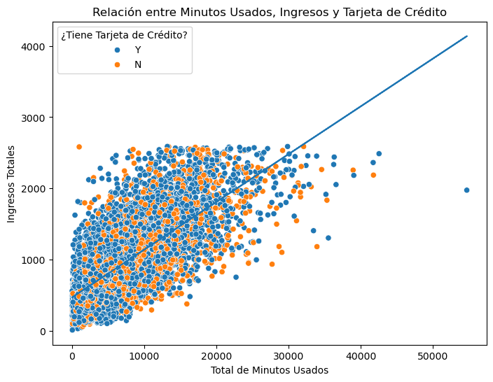

```python
plt.figure(figsize=(8, 6))
sns.scatterplot(x='totmou', y='totrev', hue='creditcd', data=df_ajust)
plt.plot(Xentre,Ypredict)
plt.title('Relación entre Minutos Usados, Ingresos y Tarjeta de Crédito')
plt.xlabel('Total de Minutos Usados')
plt.ylabel('Ingresos Totales')
plt.legend(title='¿Tiene Tarjeta de Crédito?')
plt.show()
```

## Conclusion

Al revisar la agresión lineal calculamos 2 metricas, el error cuadrántico, el cual tiene un valor bastante alto, y el puntaje de la varianza o el R score, el cual debería ser cercano a uno para indicar la buena relación de las variables, en este caso el R-score esta en el 0.52, asi pues, los indicadores nos dicen que la regresión lineal está abarcando el valor promedio de los datos y aunque los indicadores no son tan favorables no quiere decir que estos no pueda servir, como vemos en el grafico, lo que sucede es que los datos estan muy dispersos y al rededor de la regresion, lograndose ajustarse a la relación positiva que tienen los datos.

De seguro esta regresión puede ser un punto de partida para entender el comportamiento de diferentes grupos de mercado, cambiando el punto de corte con el eje Y (los ingresos totales) para empezar clasificar los clientes qué estan por encima o por debajo de la regresión, según la eficiencia Qué tienen el consumo minutos versus el ingreso que generan estos clientes, en otras palabras las diferentes tarifas que los clientes tienen asignadas.

## Prediccion

Queremos revisar cómo se comporta el modelo de regresión con los valores que fueron sacados del estudio porque superaban 2 veces la desviación estándar

```python
df_ajust2 = df_clean[df_clean['lim_ingreso'] == 0]
# se hace la prediccion de los datos
Xrev = np.array(df_ajust2[['totmou']])
Yrev = df_ajust2[['totrev']].values
Ypredict2 = regr.predict(Xrev)
print('Error cuadrado medio: %.2f' % mean_squared_error(Yrev, Ypredict2))
print('Puntaje de la varianza: %.2f'% r2_score(Yrev, Ypredict2))
```

```
Error cuadrado medio: 2814434.80
Puntaje de la varianza: -0.36
```

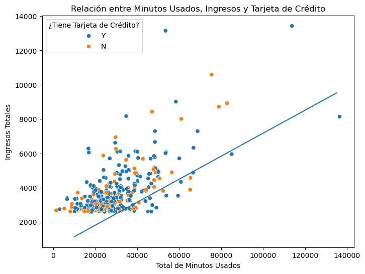

```python
x = [[10000],[135000]]
y = regr.predict(x)

plt.figure(figsize=(8, 6))
sns.scatterplot(x='totmou', y='totrev', hue='creditcd', data=df_ajust2)
plt.plot(x,y)
plt.title('Relación entre Minutos Usados, Ingresos y Tarjeta de Crédito')
plt.xlabel('Total de Minutos Usados')
plt.ylabel('Ingresos Totales')
plt.legend(title='¿Tiene Tarjeta de Crédito?')
plt.show()
```

Lo que encontramos al realizar la revisión del R score es que su valor es negativo, indicando que el modelo actúa de una peor manera que tratar de encontrar la media de los datos, para los datos que estan fuera de 2 desviaciones estandar. Es decir que el modelo no es muy bueno para predecir estos puntos extremos y por eso fue una buena idea haberlos sacado del estudio de la regresión lineal. Como se puede analizar en la grafica, la regresion se desvia de los datos, por lo que no es un buen modelo para estos. asi que lo mas interesante es considerar estos datos para un nuevo modelo para dar una explicacion a los mismos y lograr encontrar comportamientos en ellos.

## Conclusión General:

En todos los análisis realizados sobre la relación entre el total de minutos utilizados por los clientes y sus ingresos totales, se observa consistentemente una tendencia positiva: a mayor uso de minutos, los ingresos tienden a aumentar. Sin embargo, esta relación no es perfectamente lineal y está influenciada por otros factores, lo que se refleja en la dispersión de los datos y la presencia de valores atípicos.

A pesar de que los clientes con mayor uso de minutos tienden a generar más ingresos, la mayoría de ellos se concentra en niveles más bajos tanto de uso como de ingresos. Además, la posesión de una tarjeta de crédito no parece influir significativamente en esta relación, aunque se observan pequeñas diferencias en los rangos más altos de uso de minutos.

En resumen, la relación positiva entre minutos usados y ingresos es clara, pero existen otros elementos que afectan esta correlación, sugiriendo que el comportamiento del cliente no depende únicamente de su uso de minutos, y factores como los ingresos atípicos y otros comportamientos podrían ser relevantes para un análisis más profundo.

El análisis desarrollado muestra una compensación positiva entre el total de minutos consumidos por los clientes y el total de ingresos. Esto es, mientras mayor sea el consumo de minutos, mayores serán los ingresos para la compañía. Sin embargo, esta relación no depende en una línea perfecta; otros factores influyen en los ingresos individualizados de cada cliente.